# Fresh Segments

```python
from IPython.core.interactiveshell import InteractiveShell

InteractiveShell.ast_node_interactivity = "all"

import os
import sys
from typing import Dict, Optional, Tuple

import matplotlib.pyplot as plt
import numpy as np
import pandas as pd
import pymc as pm
import seaborn as sns

sys.path.append("../../../")
from src.athena import Athena
from src.utils import create_session
```

from IPython.core.interactiveshell import InteractiveShell InteractiveShell.ast_node_interactivity = "all" import os import sys from typing import Dict, Optional, Tuple import matplotlib.pyplot as plt import numpy as np import pandas as pd import pymc as pm import seaborn as sns sys.path.append("../../../") from src.athena import Athena from src.utils import create_session

## Global

```python
boto3_session = create_session(
    profile_name="dev",
    role_arn=os.getenv("ATHENA_IAM_ROLE_ARN"),
)

wait = True
ctas_approach = False
storage_format = "PARQUET"
write_compression = "SNAPPY"

database = "fresh_segments"
tables = ["interest_map", "interest_metrics"]

athena = Athena(boto3_session=boto3_session, s3_output=os.getenv("ATHENA_S3_OUTPUT"))
athena
```

boto3_session = create_session( profile_name="dev", role_arn=os.getenv("ATHENA_IAM_ROLE_ARN"), ) wait = True ctas_approach = False storage_format = "PARQUET" write_compression = "SNAPPY" database = "fresh_segments" tables = ["interest_map", "interest_metrics"] athena = Athena(boto3_session=boto3_session, s3_output=os.getenv("ATHENA_S3_OUTPUT")) athena

```
Athena(boto3_session=Session(region_name='us-east-1'), s3_output=s3://sql-case-studies/query_results)
```

## Problem Statement

Fresh Segments is a digital marketing agency specializing in analyzing trends in online ad click behavior for businesses with targeted customer bases. The agency receives customer lists from clients and aggregates interest metrics to create a comprehensive dataset for further analysis.

The main output includes detailed composition and rankings of various interests, highlighting the proportion of customers who engaged with online assets related to each interest on a monthly basis.

The goal of this case study is to analyze these aggregated metrics for a sample client to provide high-level insights into their customer base and associated interests.

## Entity Relationship Diagram

[figure not shown]

## Tables

```python
for table in tables:
    athena.query(
        database=database,
        query=f"""
                SELECT
                    *
                FROM
                    {database}.{table} TABLESAMPLE BERNOULLI(30);
              """,
        ctas_approach=ctas_approach,
    )
```

for table in tables: athena.query( database=database, query=f""" SELECT * FROM {database}.{table} TABLESAMPLE BERNOULLI(30); """, ctas_approach=ctas_approach, )

|  | id | interest_name | interest_summary | created_at | last_modified |
| --- | --- | --- | --- | --- | --- |
| 0 | 1 | Fitness Enthusiasts | Consumers using fitness tracking apps and webs... | 2016-05-26 14:57:59 | 2018-05-23 11:30:12 |
| 1 | 5 | Brides & Wedding Planners | People researching wedding ideas and vendors. | 2016-05-26 14:57:59 | 2018-05-23 11:30:12 |
| 2 | 6 | Vacation Planners | Consumers reading reviews of vacation destinat... | 2016-05-26 14:57:59 | 2018-05-23 11:30:13 |
| 3 | 8 | Business News Readers | Readers of online business news content. | 2016-05-26 14:57:59 | 2018-05-23 11:30:12 |
| 4 | 12 | Thrift Store Shoppers | Consumers shopping online for clothing at thri... | 2016-05-26 14:57:59 | 2018-03-16 13:14:00 |
| ... | ... | ... | ... | ... | ... |
| 366 | 47850 | Asheville Trip Planners | People researching attractions and accommodati... | 2019-03-15 22:00:02 | 2019-03-21 15:33:09 |
| 367 | 48154 | Elite Cycling Gear Shoppers | Consumers researching and shopping for elite c... | 2019-03-21 22:00:00 | 2019-03-22 15:31:46 |
| 368 | 48465 | HGTV Enthusiasts | People interested in HGTV shows and home remod... | 2019-03-27 22:00:01 | 2019-04-02 16:17:29 |
| 369 | 50860 | Food Delivery Service Users | Users of online food delivery services. | 2019-04-23 18:00:02 | 2019-04-24 18:30:04 |
| 370 | 51119 | Skin Disorder Researchers | People reading news and advice on preventing a... | 2019-04-26 18:00:00 | 2019-04-29 14:20:04 |

371 rows × 5 columns

|  | record_month | record_year | month_year | interest_id | composition | index_value | ranking | percentile_ranking |
| --- | --- | --- | --- | --- | --- | --- | --- | --- |
| 0 | 7 | 2018 | 07-2018 | 32486 | 11.89 | 6.19 | 1 | 99.86 |
| 1 | 7 | 2018 | 07-2018 | 18923 | 10.85 | 5.29 | 3 | 99.59 |
| 2 | 7 | 2018 | 07-2018 | 6110 | 11.57 | 4.79 | 11 | 98.49 |
| 3 | 7 | 2018 | 07-2018 | 4 | 13.97 | 4.53 | 14 | 98.08 |
| 4 | 7 | 2018 | 07-2018 | 17 | 7.89 | 4.15 | 19 | 97.39 |
| ... | ... | ... | ... | ... | ... | ... | ... | ... |
| 4307 | <NA> | <NA> | <NA> | <NA> | 1.54 | 0.77 | 1181 | 1.09 |
| 4308 | <NA> | <NA> | <NA> | <NA> | 1.94 | 0.77 | 1181 | 1.09 |
| 4309 | <NA> | <NA> | <NA> | <NA> | 1.62 | 0.74 | 1187 | 0.59 |
| 4310 | <NA> | <NA> | <NA> | <NA> | 1.62 | 0.68 | 1191 | 0.25 |
| 4311 | <NA> | <NA> | <NA> | <NA> | 1.64 | 0.62 | 1194 | 0.00 |

4312 rows × 8 columns

### Duplicate Check

Group by all columns and count the occurrences, while excluding rows with NULL values to simplify the grouping process.

#### Interest Metrics

```python
query = """
WITH grouped_counts AS (
  SELECT
    record_month,
    record_year,
    month_year,
    interest_id,
    composition,
    index_value,
    ranking,
    percentile_ranking,
    COUNT(*) AS freq
  FROM
    fresh_segments.interest_metrics
  WHERE
    record_month IS NOT NULL
    AND record_year IS NOT NULL
    AND month_year IS NOT NULL
    AND interest_id IS NOT NULL
  GROUP BY
    record_month,
    record_year,
    month_year,
    interest_id,
    composition,
    index_value,
    ranking,
    percentile_ranking
)
SELECT
  *
FROM
  grouped_counts
WHERE
  freq > 1
ORDER BY
  freq DESC;
"""

athena.query(database=database, query=query, ctas_approach=ctas_approach)
```

query = """ WITH grouped_counts AS ( SELECT record_month, record_year, month_year, interest_id, composition, index_value, ranking, percentile_ranking, COUNT(*) AS freq FROM fresh_segments.interest_metrics WHERE record_month IS NOT NULL AND record_year IS NOT NULL AND month_year IS NOT NULL AND interest_id IS NOT NULL GROUP BY record_month, record_year, month_year, interest_id, composition, index_value, ranking, percentile_ranking ) SELECT * FROM grouped_counts WHERE freq > 1 ORDER BY freq DESC; """ athena.query(database=database, query=query, ctas_approach=ctas_approach)

|  | record_month | record_year | month_year | interest_id | composition | index_value | ranking | percentile_ranking | freq |
| --- | --- | --- | --- | --- | --- | --- | --- | --- | --- |

No duplicate are identified in the table.

### NULL Check

Number of NULL values in each column.

```python
query = """
SELECT
    SUM(CASE WHEN record_month IS NULL THEN 1 ELSE 0 END) AS record_month_null,
    SUM(CASE WHEN record_year IS NULL THEN 1 ELSE 0 END) AS record_year_null,
    SUM(CASE WHEN month_year IS NULL THEN 1 ELSE 0 END) AS month_year_null,
    SUM(CASE WHEN interest_id IS NULL THEN 1 ELSE 0 END) AS interest_id_null,
    SUM(CASE WHEN composition IS NULL THEN 1 ELSE 0 END) AS composition_null,
    SUM(CASE WHEN index_value IS NULL THEN 1 ELSE 0 END) AS index_value_null,
    SUM(CASE WHEN ranking IS NULL THEN 1 ELSE 0 END) AS ranking_null,
    SUM(CASE WHEN percentile_ranking IS NULL THEN 1 ELSE 0 END) AS percentile_ranking_null
FROM
    fresh_segments.interest_metrics;
"""

athena.query(database=database, query=query, ctas_approach=ctas_approach)
```

query = """ SELECT SUM(CASE WHEN record_month IS NULL THEN 1 ELSE 0 END) AS record_month_null, SUM(CASE WHEN record_year IS NULL THEN 1 ELSE 0 END) AS record_year_null, SUM(CASE WHEN month_year IS NULL THEN 1 ELSE 0 END) AS month_year_null, SUM(CASE WHEN interest_id IS NULL THEN 1 ELSE 0 END) AS interest_id_null, SUM(CASE WHEN composition IS NULL THEN 1 ELSE 0 END) AS composition_null, SUM(CASE WHEN index_value IS NULL THEN 1 ELSE 0 END) AS index_value_null, SUM(CASE WHEN ranking IS NULL THEN 1 ELSE 0 END) AS ranking_null, SUM(CASE WHEN percentile_ranking IS NULL THEN 1 ELSE 0 END) AS percentile_ranking_null FROM fresh_segments.interest_metrics; """ athena.query(database=database, query=query, ctas_approach=ctas_approach)

|  | record_month_null | record_year_null | month_year_null | interest_id_null | composition_null | index_value_null | ranking_null | percentile_ranking_null |
| --- | --- | --- | --- | --- | --- | --- | --- | --- |
| 0 | 1194 | 1194 | 1194 | 1193 | 0 | 0 | 0 | 0 |

## Q1 & Q3

There are two preprocessing steps that can be helpful:

1. Update the `fresh_segments.interest_metrics` table by modifying the `month_year` column to be a `DATE` data type with the start of the month as the day.
2. Handling the null values in the `fresh_segments.interest_metrics` table.

First, check if there are any records with non-missing interest ID but missing `month_year` value:

```python
query = """
SELECT
    interest_id
FROM
    fresh_segments.interest_metrics
WHERE
    1 = 1
    AND month_year IS NULL
    AND interest_id IS NOT NULL;
"""

athena.query(database=database, query=query, ctas_approach=ctas_approach)
```

query = """ SELECT interest_id FROM fresh_segments.interest_metrics WHERE 1 = 1 AND month_year IS NULL AND interest_id IS NOT NULL; """ athena.query(database=database, query=query, ctas_approach=ctas_approach)

|  | interest_id |
| --- | --- |
| 0 | 21246 |

### Missing Both ID & Date

For all records that have both missing `month_year` and `interest_id` values in the `fresh_segments.interest_metrics` table, we unfortunately cannot make any good business interpretations on their interest metrics since we do not know what interest they are associated with.

### Missing Date

For the record where the `interest_id` is known (specifically `interest_id = 21246`) but the `month_year` value is missing, we want to determine if there are other records in the dataset with the same `interest_id` that have a `month_year` value that is not missing. This allows us to potentially infer or cross-reference information about the missing `month_year` value.

```python
query = """
SELECT
    *
FROM
    fresh_segments.interest_metrics
WHERE
    interest_id = 21246;
"""

athena.query(database=database, query=query, ctas_approach=ctas_approach)
```

query = """ SELECT * FROM fresh_segments.interest_metrics WHERE interest_id = 21246; """ athena.query(database=database, query=query, ctas_approach=ctas_approach)

|  | record_month | record_year | month_year | interest_id | composition | index_value | ranking | percentile_ranking |
| --- | --- | --- | --- | --- | --- | --- | --- | --- |
| 0 | 7 | 2018 | 07-2018 | 21246 | 2.26 | 0.65 | 722 | 0.96 |
| 1 | 8 | 2018 | 08-2018 | 21246 | 2.13 | 0.59 | 765 | 0.26 |
| 2 | 9 | 2018 | 09-2018 | 21246 | 2.06 | 0.61 | 774 | 0.77 |
| 3 | 10 | 2018 | 10-2018 | 21246 | 1.74 | 0.58 | 855 | 0.23 |
| 4 | 11 | 2018 | 11-2018 | 21246 | 2.25 | 0.78 | 908 | 2.16 |
| 5 | 12 | 2018 | 12-2018 | 21246 | 1.97 | 0.70 | 983 | 1.21 |
| 6 | 1 | 2019 | 01-2019 | 21246 | 2.05 | 0.76 | 954 | 1.95 |
| 7 | 2 | 2019 | 02-2019 | 21246 | 1.84 | 0.68 | 1109 | 1.07 |
| 8 | 3 | 2019 | 03-2019 | 21246 | 1.75 | 0.67 | 1123 | 1.14 |
| 9 | 4 | 2019 | 04-2019 | 21246 | 1.58 | 0.63 | 1092 | 0.64 |
| 10 | <NA> | <NA> | <NA> | 21246 | 1.61 | 0.68 | 1191 | 0.25 |

In this case, the options are:

- Impute the missing `month_year` value with the `month_year` value of the lateset record with the same `interest_id` value
- Impute the missing `month_year` value with the `created_at` value from the `fresh_segments.interest_map` table
- Drop the record

The first two options run the risk of introducing bias into the data, but dropping the record may result in a loss of valuable information. Given that there is only one record with a missing `month_year` value, we can argue that the risk of losing valuable information is low relative to the risk of introducing bias into the data by imputing date information.

```python
# New ctas table with modified column and dropping all records with missing date information
query = """
SELECT
    record_month,
    record_year,
    CASE WHEN month_year IS NULL THEN NULL ELSE DATE_PARSE(CONCAT_WS('-', '01', month_year), '%d-%m-%Y') END AS month_year,
    interest_id,
    composition,
    index_value,
    ranking,
    percentile_ranking
FROM
    fresh_segments.interest_metrics
WHERE
    month_year IS NOT NULL;
"""

athena.create_ctas_table(
    database=database,
    query=query,
    ctas_table="interest_metrics_modified",
    s3_output="s3://sql-case-studies/fresh_segments/interest_metrics/",
    storage_format=storage_format,
    write_compression=write_compression,
    wait=wait,
)

# Drop old table
athena.drop_table(database=database, table="interest_metrics")
```

# New ctas table with modified column and dropping all records with missing date information query = """ SELECT record_month, record_year, CASE WHEN month_year IS NULL THEN NULL ELSE DATE_PARSE(CONCAT_WS('-', '01', month_year), '%d-%m-%Y') END AS month_year, interest_id, composition, index_value, ranking, percentile_ranking FROM fresh_segments.interest_metrics WHERE month_year IS NOT NULL; """ athena.create_ctas_table( database=database, query=query, ctas_table="interest_metrics_modified", s3_output="s3://sql-case-studies/fresh_segments/interest_metrics/", storage_format=storage_format, write_compression=write_compression, wait=wait, ) # Drop old table athena.drop_table(database=database, table="interest_metrics")

```
{'ctas_database': 'fresh_segments',
 'ctas_table': 'interest_metrics_modified',
 'ctas_query_metadata': _QueryMetadata(execution_id='349c49e1-5136-4e2d-baad-7e7764a0c489', dtype={'rows': 'Int64'}, parse_timestamps=[], parse_dates=[], parse_geometry=[], converters={}, binaries=[], output_location='s3://sql-case-studies/fresh_segments/interest_metrics/tables/349c49e1-5136-4e2d-ba…
```

```
Query executed successfully
```

```python
# New ctas table with original name
query = """
SELECT
    *
FROM
    fresh_segments.interest_metrics_modified;
"""

athena.create_ctas_table(
    database=database,
    query=query,
    ctas_table="interest_metrics",
    s3_output="s3://sql-case-studies/fresh_segments/interest_metrics/",
    storage_format=storage_format,
    write_compression=write_compression,
    wait=wait,
)

# Drop temporary ctas table
athena.drop_table(database=database, table="interest_metrics_modified")
```

# New ctas table with original name query = """ SELECT * FROM fresh_segments.interest_metrics_modified; """ athena.create_ctas_table( database=database, query=query, ctas_table="interest_metrics", s3_output="s3://sql-case-studies/fresh_segments/interest_metrics/", storage_format=storage_format, write_compression=write_compression, wait=wait, ) # Drop temporary ctas table athena.drop_table(database=database, table="interest_metrics_modified")

```
{'ctas_database': 'fresh_segments',
 'ctas_table': 'interest_metrics',
 'ctas_query_metadata': _QueryMetadata(execution_id='cc381175-9e88-4338-8acc-44814a4465b5', dtype={'rows': 'Int64'}, parse_timestamps=[], parse_dates=[], parse_geometry=[], converters={}, binaries=[], output_location='s3://sql-case-studies/fresh_segments/interest_metrics/tables/cc381175-9e88-4338-8a…
```

```
Query executed successfully
```

```python
query = """
SELECT
    *
FROM
    fresh_segments.interest_metrics TABLESAMPLE BERNOULLI(30);
"""

athena.query(database=database, query=query, ctas_approach=ctas_approach)
```

query = """ SELECT * FROM fresh_segments.interest_metrics TABLESAMPLE BERNOULLI(30); """ athena.query(database=database, query=query, ctas_approach=ctas_approach)

|  | record_month | record_year | month_year | interest_id | composition | index_value | ranking | percentile_ranking |
| --- | --- | --- | --- | --- | --- | --- | --- | --- |
| 0 | 7 | 2018 | 2018-07-01 | 6344 | 10.32 | 5.10 | 4 | 99.45 |
| 1 | 7 | 2018 | 2018-07-01 | 69 | 10.82 | 5.03 | 6 | 99.18 |
| 2 | 7 | 2018 | 2018-07-01 | 17 | 7.89 | 4.15 | 19 | 97.39 |
| 3 | 7 | 2018 | 2018-07-01 | 6286 | 14.10 | 3.82 | 25 | 96.57 |
| 4 | 7 | 2018 | 2018-07-01 | 6184 | 13.35 | 3.75 | 29 | 96.02 |
| ... | ... | ... | ... | ... | ... | ... | ... | ... |
| 3925 | 8 | 2019 | 2019-08-01 | 33957 | 1.74 | 0.93 | 1130 | 1.65 |
| 3926 | 8 | 2019 | 2019-08-01 | 136 | 1.74 | 0.93 | 1130 | 1.65 |
| 3927 | 8 | 2019 | 2019-08-01 | 16198 | 1.82 | 0.90 | 1139 | 0.87 |
| 3928 | 8 | 2019 | 2019-08-01 | 15884 | 1.68 | 0.86 | 1144 | 0.44 |
| 3929 | 8 | 2019 | 2019-08-01 | 6225 | 2.15 | 0.86 | 1144 | 0.44 |

3930 rows × 8 columns

```python
query = """
SELECT
    COUNT(*) AS record_count
FROM
    fresh_segments.interest_metrics;
"""

athena.query(database=database, query=query, ctas_approach=ctas_approach)
```

query = """ SELECT COUNT(*) AS record_count FROM fresh_segments.interest_metrics; """ athena.query(database=database, query=query, ctas_approach=ctas_approach)

|  | record_count |
| --- | --- |
| 0 | 13079 |

## Q2

What is count of records in the `fresh_segments.interest_metrics` table for each `month_year` value sorted in chronological order (earliest to latest) with the null values appearing first?

```python
query = """
SELECT
    month_year,
    COUNT(DISTINCT interest_id) AS unique_interest_count
FROM
    fresh_segments.interest_metrics
GROUP BY
    month_year
ORDER BY
    month_year ASC NULLS FIRST;
"""

athena.query(database=database, query=query, ctas_approach=ctas_approach)
```

query = """ SELECT month_year, COUNT(DISTINCT interest_id) AS unique_interest_count FROM fresh_segments.interest_metrics GROUP BY month_year ORDER BY month_year ASC NULLS FIRST; """ athena.query(database=database, query=query, ctas_approach=ctas_approach)

|  | month_year | unique_interest_count |
| --- | --- | --- |
| 0 | 2018-07-01 | 729 |
| 1 | 2018-08-01 | 767 |
| 2 | 2018-09-01 | 780 |
| 3 | 2018-10-01 | 857 |
| 4 | 2018-11-01 | 928 |
| 5 | 2018-12-01 | 995 |
| 6 | 2019-01-01 | 973 |
| 7 | 2019-02-01 | 1121 |
| 8 | 2019-03-01 | 1136 |
| 9 | 2019-04-01 | 1099 |
| 10 | 2019-05-01 | 857 |
| 11 | 2019-06-01 | 824 |
| 12 | 2019-07-01 | 864 |
| 13 | 2019-08-01 | 1149 |

## Q4

How many `interest_id` values exist in the `fresh_segments.interest_metrics` table but not in the `fresh_segments.interest_map` table? What about the other way around?

Let `A` be the set of `interest_id` values in the `fresh_segments.interest_metrics` table and `B` be the set of `interest_id` values in the `fresh_segments.interest_map` table.

### A \ B & B \ A

We can use a full outer join, which returns **all rows from both tables** regardless of whether there is a match or not:

```python
query = """
SELECT
    COUNT(DISTINCT met.interest_id) AS metrics_id_unique_count,
    COUNT(DISTINCT map.id) AS map_id_unique_count,
    SUM(CASE WHEN met.interest_id IS NULL AND map.id IS NOT NULL THEN 1 ELSE 0 END) AS in_map_not_in_metrics_count,
    SUM(CASE WHEN met.interest_id IS NOT NULL AND map.id IS NULL THEN 1 ELSE 0 END) AS in_metrics_not_in_map_count
FROM
    fresh_segments.interest_metrics AS met
        FULL JOIN fresh_segments.interest_map AS map ON met.interest_id = map.id;
"""

athena.query(database=database, query=query, ctas_approach=ctas_approach)
```

query = """ SELECT COUNT(DISTINCT met.interest_id) AS metrics_id_unique_count, COUNT(DISTINCT map.id) AS map_id_unique_count, SUM(CASE WHEN met.interest_id IS NULL AND map.id IS NOT NULL THEN 1 ELSE 0 END) AS in_map_not_in_metrics_count, SUM(CASE WHEN met.interest_id IS NOT NULL AND map.id IS NULL THEN 1 ELSE 0 END) AS in_metrics_not_in_map_count FROM fresh_segments.interest_metrics AS met FULL JOIN fresh_segments.interest_map AS map ON met.interest_id = map.id; """ athena.query(database=database, query=query, ctas_approach=ctas_approach)

|  | metrics_id_unique_count | map_id_unique_count | in_map_not_in_metrics_count | in_metrics_not_in_map_count |
| --- | --- | --- | --- | --- |
| 0 | 1202 | 1209 | 7 | 0 |

**All IDs in `interest_metrics` are also in `interest_map`:** This means that there are no interest IDs in `interest_metrics` that are missing from `interest_map`. In set notation:

- interest_metrics ∖ interest_map = ∅ (empty set)

**Some IDs in `interest_map` are not in `interest_metrics`:** There are 7 interest IDs that are found in `interest_map` but do not appear in `interest_metrics`. In set notation:

- interest_map ∖ interest_metrics = {7 IDs}`

## Q5

Summarise the `id` values in the `fresh_segments.interest_map` by its total record count in this table.

```python
query = """
SELECT
    COUNT(id) AS raw_count
FROM
    fresh_segments.interest_map;
"""

athena.query(database=database, query=query, ctas_approach=ctas_approach)
```

query = """ SELECT COUNT(id) AS raw_count FROM fresh_segments.interest_map; """ athena.query(database=database, query=query, ctas_approach=ctas_approach)

|  | raw_count |
| --- | --- |
| 0 | 1209 |

## Q6

What sort of table join would be most appropriate to combine the `fresh_segments.interest_metrics` and `fresh_segments.interest_map` tables?

A **left join** of the `interest_map` table onto `interest_metrics` is most appropriate because the asymmetric set difference shows that all `interest_id` values in `interest_metrics` are present in `interest_map`.

This ensures all rows from `interest_metrics` are retained, while relevant data from `interest_map` is included without unnecessary rows from `interest_map` that have no match in `interest_metrics`.

```python
query = """
SELECT
    met.interest_id,
    met.record_month,
    met.record_year,
    met.month_year,
    met.composition,
    met.index_value,
    met.ranking,
    met.percentile_ranking,
    map.interest_name,
    map.interest_summary,
    map.created_at,
    map.last_modified
FROM
    fresh_segments.interest_metrics AS met
        LEFT JOIN fresh_segments.interest_map AS map ON met.interest_id = map.id
WHERE
    met.interest_id = 21246;
"""

athena.query(database=database, query=query, ctas_approach=ctas_approach)
```

query = """ SELECT met.interest_id, met.record_month, met.record_year, met.month_year, met.composition, met.index_value, met.ranking, met.percentile_ranking, map.interest_name, map.interest_summary, map.created_at, map.last_modified FROM fresh_segments.interest_metrics AS met LEFT JOIN fresh_segments.interest_map AS map ON met.interest_id = map.id WHERE met.interest_id = 21246; """ athena.query(database=database, query=query, ctas_approach=ctas_approach)

|  | interest_id | record_month | record_year | month_year | composition | index_value | ranking | percentile_ranking | interest_name | interest_summary | created_at | last_modified |
| --- | --- | --- | --- | --- | --- | --- | --- | --- | --- | --- | --- | --- |
| 0 | 21246 | 7 | 2018 | 2018-07-01 | 2.26 | 0.65 | 722 | 0.96 | Readers of El Salvadoran Content | People reading news from El Salvadoran media s... | 2018-06-11 17:50:04 | 2018-06-11 17:50:04 |
| 1 | 21246 | 8 | 2018 | 2018-08-01 | 2.13 | 0.59 | 765 | 0.26 | Readers of El Salvadoran Content | People reading news from El Salvadoran media s... | 2018-06-11 17:50:04 | 2018-06-11 17:50:04 |
| 2 | 21246 | 9 | 2018 | 2018-09-01 | 2.06 | 0.61 | 774 | 0.77 | Readers of El Salvadoran Content | People reading news from El Salvadoran media s... | 2018-06-11 17:50:04 | 2018-06-11 17:50:04 |
| 3 | 21246 | 10 | 2018 | 2018-10-01 | 1.74 | 0.58 | 855 | 0.23 | Readers of El Salvadoran Content | People reading news from El Salvadoran media s... | 2018-06-11 17:50:04 | 2018-06-11 17:50:04 |
| 4 | 21246 | 11 | 2018 | 2018-11-01 | 2.25 | 0.78 | 908 | 2.16 | Readers of El Salvadoran Content | People reading news from El Salvadoran media s... | 2018-06-11 17:50:04 | 2018-06-11 17:50:04 |
| 5 | 21246 | 12 | 2018 | 2018-12-01 | 1.97 | 0.70 | 983 | 1.21 | Readers of El Salvadoran Content | People reading news from El Salvadoran media s... | 2018-06-11 17:50:04 | 2018-06-11 17:50:04 |
| 6 | 21246 | 1 | 2019 | 2019-01-01 | 2.05 | 0.76 | 954 | 1.95 | Readers of El Salvadoran Content | People reading news from El Salvadoran media s... | 2018-06-11 17:50:04 | 2018-06-11 17:50:04 |
| 7 | 21246 | 2 | 2019 | 2019-02-01 | 1.84 | 0.68 | 1109 | 1.07 | Readers of El Salvadoran Content | People reading news from El Salvadoran media s... | 2018-06-11 17:50:04 | 2018-06-11 17:50:04 |
| 8 | 21246 | 3 | 2019 | 2019-03-01 | 1.75 | 0.67 | 1123 | 1.14 | Readers of El Salvadoran Content | People reading news from El Salvadoran media s... | 2018-06-11 17:50:04 | 2018-06-11 17:50:04 |
| 9 | 21246 | 4 | 2019 | 2019-04-01 | 1.58 | 0.63 | 1092 | 0.64 | Readers of El Salvadoran Content | People reading news from El Salvadoran media s... | 2018-06-11 17:50:04 | 2018-06-11 17:50:04 |

## Q7

Are there any records in the joined table where the `month_year` value is before the `created_at` value from the `fresh_segments.interest_map` table? Are these values valid and why?

```python
query = """
SELECT
    met.interest_id,
    met.record_month,
    met.record_year,
    met.month_year,
    met.composition,
    met.index_value,
    met.ranking,
    met.percentile_ranking,
    map.interest_name,
    map.interest_summary,
    map.created_at,
    map.last_modified
FROM
    fresh_segments.interest_metrics AS met
        LEFT JOIN fresh_segments.interest_map AS map ON met.interest_id = map.id
WHERE
    met.month_year < map.created_at;
"""

athena.query(database=database, query=query, ctas_approach=ctas_approach)
```

query = """ SELECT met.interest_id, met.record_month, met.record_year, met.month_year, met.composition, met.index_value, met.ranking, met.percentile_ranking, map.interest_name, map.interest_summary, map.created_at, map.last_modified FROM fresh_segments.interest_metrics AS met LEFT JOIN fresh_segments.interest_map AS map ON met.interest_id = map.id WHERE met.month_year < map.created_at; """ athena.query(database=database, query=query, ctas_approach=ctas_approach)

|  | interest_id | record_month | record_year | month_year | composition | index_value | ranking | percentile_ranking | interest_name | interest_summary | created_at | last_modified |
| --- | --- | --- | --- | --- | --- | --- | --- | --- | --- | --- | --- | --- |
| 0 | 32704 | 7 | 2018 | 2018-07-01 | 8.04 | 2.27 | 225 | 69.14 | Major Airline Customers | People visiting sites for major airline brands... | 2018-07-06 14:35:04 | 2018-07-06 14:35:04 |
| 1 | 33191 | 7 | 2018 | 2018-07-01 | 3.99 | 2.11 | 283 | 61.18 | Online Shoppers | People who spend money online | 2018-07-17 10:40:03 | 2018-07-17 10:46:58 |
| 2 | 32703 | 7 | 2018 | 2018-07-01 | 5.53 | 1.80 | 375 | 48.56 | School Supply Shoppers | Consumers shopping for classroom supplies for ... | 2018-07-06 14:35:04 | 2018-07-06 14:35:04 |
| 3 | 32701 | 7 | 2018 | 2018-07-01 | 4.23 | 1.41 | 483 | 33.74 | Womens Equality Advocates | People visiting sites advocating for womens eq... | 2018-07-06 14:35:03 | 2018-07-06 14:35:03 |
| 4 | 32705 | 7 | 2018 | 2018-07-01 | 4.38 | 1.34 | 505 | 30.73 | Certified Events Professionals | Professionals reading industry news and resear... | 2018-07-06 14:35:04 | 2018-07-06 14:35:04 |
| ... | ... | ... | ... | ... | ... | ... | ... | ... | ... | ... | ... | ... |
| 183 | 49972 | 4 | 2019 | 2019-04-01 | 2.11 | 1.15 | 722 | 34.30 | Horseback Riding Enthusiasts | People reading horseback riding news and resou... | 2019-04-15 18:00:00 | 2019-04-24 17:40:04 |
| 184 | 49502 | 4 | 2019 | 2019-04-01 | 1.87 | 1.12 | 768 | 30.12 | Veterinarians | Veterinarians | 2019-04-08 18:00:05 | 2019-07-09 13:57:13 |
| 185 | 49974 | 4 | 2019 | 2019-04-01 | 2.00 | 1.10 | 799 | 27.30 | Agricultural and Food Issues Researchers | People researching organizations for food and ... | 2019-04-15 18:00:00 | 2019-04-24 17:40:04 |
| 186 | 49973 | 4 | 2019 | 2019-04-01 | 1.66 | 1.03 | 910 | 17.20 | Farm Finance Researchers | People researching financial institutions spec... | 2019-04-15 18:00:00 | 2019-04-24 17:40:04 |
| 187 | 51678 | 5 | 2019 | 2019-05-01 | 1.71 | 1.53 | 475 | 44.57 | Plumbers | Professionals reading industry news and resear... | 2019-05-06 22:00:00 | 2019-05-07 18:50:04 |

188 rows × 12 columns

Some `month_year` values are before the `created_at` values because the former is less granular than the latter. The `month_year` value is the month and year of the interest metrics, while the `created_at` value is the timestamp of when the interest was created. We also preprocessed the `month_year` to be the first day of the month, so it is expected that some `month_year` values will be before the `created_at` values.

We can verify that there are no records where the difference between the `month_year` and `created_at` values is greater than 1 month, which would suggest that there are data quality issues.

```python
query = """
SELECT
    met.interest_id,
    met.record_month,
    met.record_year,
    met.month_year,
    met.composition,
    met.index_value,
    met.ranking,
    met.percentile_ranking,
    map.interest_name,
    map.interest_summary,
    map.created_at,
    map.last_modified
FROM
    fresh_segments.interest_metrics AS met
        LEFT JOIN fresh_segments.interest_map AS map ON met.interest_id = map.id
WHERE
    met.month_year < map.created_at
    AND DATE_DIFF('DAY', met.month_year, map.created_at) > 30;
"""

athena.query(database=database, query=query, ctas_approach=ctas_approach)
```

query = """ SELECT met.interest_id, met.record_month, met.record_year, met.month_year, met.composition, met.index_value, met.ranking, met.percentile_ranking, map.interest_name, map.interest_summary, map.created_at, map.last_modified FROM fresh_segments.interest_metrics AS met LEFT JOIN fresh_segments.interest_map AS map ON met.interest_id = map.id WHERE met.month_year < map.created_at AND DATE_DIFF('DAY', met.month_year, map.created_at) > 30; """ athena.query(database=database, query=query, ctas_approach=ctas_approach)

|  | interest_id | record_month | record_year | month_year | composition | index_value | ranking | percentile_ranking | interest_name | interest_summary | created_at | last_modified |
| --- | --- | --- | --- | --- | --- | --- | --- | --- | --- | --- | --- | --- |

Another way to verfiy is to use `DATE_TRUNC` function to truncate the `created_at` values to the month level (i.e., first day of each `created_at` month) and compare the `month_year` values with the truncated `created_at` values.

```python
query = """
SELECT
    met.interest_id,
    met.record_month,
    met.record_year,
    met.month_year,
    met.composition,
    met.index_value,
    met.ranking,
    met.percentile_ranking,
    map.interest_name,
    map.interest_summary,
    map.created_at,
    map.last_modified
FROM
    fresh_segments.interest_metrics AS met
        LEFT JOIN fresh_segments.interest_map AS map ON met.interest_id = map.id
WHERE
    met.month_year < DATE_TRUNC('MONTH', map.created_at);
"""

athena.query(database=database, query=query, ctas_approach=ctas_approach)
```

query = """ SELECT met.interest_id, met.record_month, met.record_year, met.month_year, met.composition, met.index_value, met.ranking, met.percentile_ranking, map.interest_name, map.interest_summary, map.created_at, map.last_modified FROM fresh_segments.interest_metrics AS met LEFT JOIN fresh_segments.interest_map AS map ON met.interest_id = map.id WHERE met.month_year < DATE_TRUNC('MONTH', map.created_at); """ athena.query(database=database, query=query, ctas_approach=ctas_approach)

|  | interest_id | record_month | record_year | month_year | composition | index_value | ranking | percentile_ranking | interest_name | interest_summary | created_at | last_modified |
| --- | --- | --- | --- | --- | --- | --- | --- | --- | --- | --- | --- | --- |

## Q1

Which interests have been present in all `month_year` dates in our dataset?

```python
query = """
SELECT
    map.interest_name,
    COUNT(DISTINCT met.month_year) AS total_monthS
FROM
    fresh_segments.interest_metrics AS met
        LEFT JOIN fresh_segments.interest_map AS map ON met.interest_id = map.id
GROUP BY
    interest_name
HAVING
    COUNT(DISTINCT met.month_year) = (
        SELECT COUNT(DISTINCT month_year)
        FROM fresh_segments.interest_metrics
    )
ORDER BY
    interest_name ASC;
"""

athena.query(database=database, query=query, ctas_approach=ctas_approach)
```

query = """ SELECT map.interest_name, COUNT(DISTINCT met.month_year) AS total_monthS FROM fresh_segments.interest_metrics AS met LEFT JOIN fresh_segments.interest_map AS map ON met.interest_id = map.id GROUP BY interest_name HAVING COUNT(DISTINCT met.month_year) = ( SELECT COUNT(DISTINCT month_year) FROM fresh_segments.interest_metrics ) ORDER BY interest_name ASC; """ athena.query(database=database, query=query, ctas_approach=ctas_approach)

|  | interest_name | total_monthS |
| --- | --- | --- |
| 0 | Accounting & CPA Continuing Education Researchers | 14 |
| 1 | Affordable Hotel Bookers | 14 |
| 2 | Aftermarket Accessories Shoppers | 14 |
| 3 | Alabama Trip Planners | 14 |
| 4 | Alaskan Cruise Planners | 14 |
| ... | ... | ... |
| 475 | World Cup Enthusiasts | 14 |
| 476 | Yachting Enthusiasts | 14 |
| 477 | Yale University Fans | 14 |
| 478 | Yogis | 14 |
| 479 | Zoo Visitors | 14 |

480 rows × 2 columns

```python
query = """
WITH count_month_year AS (
    SELECT
        interest_id,
        COUNT(DISTINCT month_year) AS total_months
    FROM
        fresh_segments.interest_metrics
    GROUP BY
        interest_id
)
SELECT
    total_months,
    COUNT(DISTINCT interest_id) AS interest_counts
FROM
    count_month_year
GROUP BY
    total_months
ORDER BY
    total_months DESC;
"""

athena.query(database=database, query=query, ctas_approach=ctas_approach)
```

query = """ WITH count_month_year AS ( SELECT interest_id, COUNT(DISTINCT month_year) AS total_months FROM fresh_segments.interest_metrics GROUP BY interest_id ) SELECT total_months, COUNT(DISTINCT interest_id) AS interest_counts FROM count_month_year GROUP BY total_months ORDER BY total_months DESC; """ athena.query(database=database, query=query, ctas_approach=ctas_approach)

|  | total_months | interest_counts |
| --- | --- | --- |
| 0 | 14 | 480 |
| 1 | 13 | 82 |
| 2 | 12 | 65 |
| 3 | 11 | 94 |
| 4 | 10 | 86 |
| 5 | 9 | 95 |
| 6 | 8 | 67 |
| 7 | 7 | 90 |
| 8 | 6 | 33 |
| 9 | 5 | 38 |
| 10 | 4 | 32 |
| 11 | 3 | 15 |
| 12 | 2 | 12 |
| 13 | 1 | 13 |

## Q2

Using this same `total_months` measure, calculate the cumulative percentage of all records starting at 14 months - which `total_months` value passes the $90\%$ cumulative percentage value?

```python
query = """
WITH count_month_year AS (
    SELECT
        interest_id,
        COUNT(DISTINCT month_year) AS total_months
    FROM
        fresh_segments.interest_metrics
    GROUP BY
        interest_id
),

count_interest_by_total_months AS (
    SELECT
        total_months,
        COUNT(DISTINCT interest_id) AS interest_counts
    FROM
        count_month_year
    GROUP BY
        total_months
)

SELECT
    total_months,
    interest_counts,
    ROUND(
        100.0 * SUM(interest_counts) OVER (
            ORDER BY total_months DESC
            ROWS BETWEEN UNBOUNDED PRECEDING AND CURRENT ROW
        ) / SUM(interest_counts) OVER(),
        2
    ) AS cumulative_percentage
FROM
    count_interest_by_total_months
ORDER BY
    total_months DESC;
"""

athena.query(database=database, query=query, ctas_approach=ctas_approach)
```

query = """ WITH count_month_year AS ( SELECT interest_id, COUNT(DISTINCT month_year) AS total_months FROM fresh_segments.interest_metrics GROUP BY interest_id ), count_interest_by_total_months AS ( SELECT total_months, COUNT(DISTINCT interest_id) AS interest_counts FROM count_month_year GROUP BY total_months ) SELECT total_months, interest_counts, ROUND( 100.0 * SUM(interest_counts) OVER ( ORDER BY total_months DESC ROWS BETWEEN UNBOUNDED PRECEDING AND CURRENT ROW ) / SUM(interest_counts) OVER(), 2 ) AS cumulative_percentage FROM count_interest_by_total_months ORDER BY total_months DESC; """ athena.query(database=database, query=query, ctas_approach=ctas_approach)

|  | total_months | interest_counts | cumulative_percentage |
| --- | --- | --- | --- |
| 0 | 14 | 480 | 39.93 |
| 1 | 13 | 82 | 46.76 |
| 2 | 12 | 65 | 52.16 |
| 3 | 11 | 94 | 59.98 |
| 4 | 10 | 86 | 67.14 |
| 5 | 9 | 95 | 75.04 |
| 6 | 8 | 67 | 80.62 |
| 7 | 7 | 90 | 88.10 |
| 8 | 6 | 33 | 90.85 |
| 9 | 5 | 38 | 94.01 |
| 10 | 4 | 32 | 96.67 |
| 11 | 3 | 15 | 97.92 |
| 12 | 2 | 12 | 98.92 |
| 13 | 1 | 13 | 100.00 |

## Q3

If we were to remove all `interest_id` values which are lower than the `total_months` value we found in the previous question - how many total data points would we be removing?

```python
query = """
WITH interest_ids_to_remove AS (
    SELECT
        interest_id
    FROM
        fresh_segments.interest_metrics
    GROUP BY
        interest_id
    HAVING
        COUNT(DISTINCT month_year) < 6
)

SELECT
    COUNT(met.interest_id) AS remove_row_count
FROM
    fresh_segments.interest_metrics AS met
        LEFT JOIN interest_ids_to_remove AS remove ON met.interest_id = remove.interest_id
WHERE
    1 = 1
    AND remove.interest_id IS NOT NULL;
"""

athena.query(database=database, query=query, ctas_approach=ctas_approach)
```

query = """ WITH interest_ids_to_remove AS ( SELECT interest_id FROM fresh_segments.interest_metrics GROUP BY interest_id HAVING COUNT(DISTINCT month_year) < 6 ) SELECT COUNT(met.interest_id) AS remove_row_count FROM fresh_segments.interest_metrics AS met LEFT JOIN interest_ids_to_remove AS remove ON met.interest_id = remove.interest_id WHERE 1 = 1 AND remove.interest_id IS NOT NULL; """ athena.query(database=database, query=query, ctas_approach=ctas_approach)

|  | remove_row_count |
| --- | --- |
| 0 | 400 |

## Q4

Does it make sense to remove these data points from a business perspective? Consider an example where an interest has data for all 14 months compared to one with significantly fewer months, and evaluate what having fewer months of data implies from a segmentation perspective. Additionally, if we include all interests regardless of the number of months they appear, how many unique interests are represented in each month?

```python
query = """
SELECT
    month_year,
    COUNT(DISTINCT interest_id) AS num_unique_interest
FROM
    fresh_segments.interest_metrics
GROUP BY
    month_year
ORDER BY
    num_unique_interest DESC;
"""

athena.query(database=database, query=query, ctas_approach=ctas_approach)
```

query = """ SELECT month_year, COUNT(DISTINCT interest_id) AS num_unique_interest FROM fresh_segments.interest_metrics GROUP BY month_year ORDER BY num_unique_interest DESC; """ athena.query(database=database, query=query, ctas_approach=ctas_approach)

|  | month_year | num_unique_interest |
| --- | --- | --- |
| 0 | 2019-08-01 | 1149 |
| 1 | 2019-03-01 | 1136 |
| 2 | 2019-02-01 | 1121 |
| 3 | 2019-04-01 | 1099 |
| 4 | 2018-12-01 | 995 |
| 5 | 2019-01-01 | 973 |
| 6 | 2018-11-01 | 928 |
| 7 | 2019-07-01 | 864 |
| 8 | 2018-10-01 | 857 |
| 9 | 2019-05-01 | 857 |
| 10 | 2019-06-01 | 824 |
| 11 | 2018-09-01 | 780 |
| 12 | 2018-08-01 | 767 |
| 13 | 2018-07-01 | 729 |

Metrics computed for interests with limited availability during the sampling period may lead to less reliable or, even worse, biased results. Furthermore, conducting statistical hypothesis testing on smaller sample sizes may reduce the statistical power, making it more challenging to detect true effects.

## Q1

Using the complete dataset - which are the top 10 and bottom 10 interests that have the largest composition values in any `month_year`? Only use the **maximum composition value** for each interest but keep the corresponding `month_year`.

```python
query = """
WITH compositions AS (
    SELECT
        map.interest_name,
        met.month_year,
        met.composition,
        DENSE_RANK() OVER (
            PARTITION BY map.interest_name
            ORDER BY met.composition DESC
        ) AS comp_ranks
    FROM
        fresh_segments.interest_metrics AS met
    LEFT JOIN
        fresh_segments.interest_map AS map
    ON
        met.interest_id = map.id
),

top_10 AS (
    SELECT
        interest_name,
        month_year,
        composition,
        'top_10' AS rank
    FROM
        compositions
    WHERE
        comp_ranks = 1
    ORDER BY
        composition DESC
    LIMIT
        10
),

bottom_10 AS (
    SELECT
        interest_name,
        month_year,
        composition,
        'bottom_10' AS rank
    FROM
        compositions
    WHERE
        comp_ranks = 1
    ORDER BY
        composition ASC
    LIMIT
        10
),

row_bind AS (
    SELECT * FROM top_10
    UNION
    SELECT * FROM bottom_10
)
SELECT
    *
FROM
    row_bind
ORDER BY
    rank DESC,
    composition DESC;
"""

athena.query(database=database, query=query, ctas_approach=ctas_approach)
```

query = """ WITH compositions AS ( SELECT map.interest_name, met.month_year, met.composition, DENSE_RANK() OVER ( PARTITION BY map.interest_name ORDER BY met.composition DESC ) AS comp_ranks FROM fresh_segments.interest_metrics AS met LEFT JOIN fresh_segments.interest_map AS map ON met.interest_id = map.id ), top_10 AS ( SELECT interest_name, month_year, composition, 'top_10' AS rank FROM compositions WHERE comp_ranks = 1 ORDER BY composition DESC LIMIT 10 ), bottom_10 AS ( SELECT interest_name, month_year, composition, 'bottom_10' AS rank FROM compositions WHERE comp_ranks = 1 ORDER BY composition ASC LIMIT 10 ), row_bind AS ( SELECT * FROM top_10 UNION SELECT * FROM bottom_10 ) SELECT * FROM row_bind ORDER BY rank DESC, composition DESC; """ athena.query(database=database, query=query, ctas_approach=ctas_approach)

|  | interest_name | month_year | composition | rank |
| --- | --- | --- | --- | --- |
| 0 | Work Comes First Travelers | 2018-12-01 | 21.20 | top_10 |
| 1 | Gym Equipment Owners | 2018-07-01 | 18.82 | top_10 |
| 2 | Furniture Shoppers | 2018-07-01 | 17.44 | top_10 |
| 3 | Luxury Retail Shoppers | 2018-07-01 | 17.19 | top_10 |
| 4 | Luxury Boutique Hotel Researchers | 2018-10-01 | 15.15 | top_10 |
| 5 | Luxury Bedding Shoppers | 2018-12-01 | 15.05 | top_10 |
| 6 | Shoe Shoppers | 2018-07-01 | 14.91 | top_10 |
| 7 | Cosmetics and Beauty Shoppers | 2018-07-01 | 14.23 | top_10 |
| 8 | Luxury Hotel Guests | 2018-07-01 | 14.10 | top_10 |
| 9 | Luxury Retail Researchers | 2018-07-01 | 13.97 | top_10 |
| 10 | Readers of Jamaican Content | 2018-07-01 | 1.86 | bottom_10 |
| 11 | Automotive News Readers | 2019-02-01 | 1.84 | bottom_10 |
| 12 | Comedy Fans | 2018-07-01 | 1.83 | bottom_10 |
| 13 | World of Warcraft Enthusiasts | 2019-08-01 | 1.82 | bottom_10 |
| 14 | Miami Heat Fans | 2018-08-01 | 1.81 | bottom_10 |
| 15 | Online Role Playing Game Enthusiasts | 2018-07-01 | 1.73 | bottom_10 |
| 16 | Hearthstone Video Game Fans | 2019-08-01 | 1.66 | bottom_10 |
| 17 | Scifi Movie and TV Enthusiasts | 2018-09-01 | 1.61 | bottom_10 |
| 18 | Action Movie and TV Enthusiasts | 2018-09-01 | 1.59 | bottom_10 |
| 19 | The Sims Video Game Fans | 2019-03-01 | 1.57 | bottom_10 |

## Q2

Which 5 interests had the lowest average `ranking` value?

```python
query = """
SELECT
    map.interest_name,
    AVG(met.ranking) AS avg_ranking,
    COUNT(*) AS n
FROM
    fresh_segments.interest_metrics AS met
        LEFT JOIN fresh_segments.interest_map AS map ON met.interest_id = map.id
GROUP BY
    map.interest_name
ORDER BY
    avg_ranking DESC
LIMIT
    5;
"""

athena.query(database=database, query=query, ctas_approach=ctas_approach)
```

query = """ SELECT map.interest_name, AVG(met.ranking) AS avg_ranking, COUNT(*) AS n FROM fresh_segments.interest_metrics AS met LEFT JOIN fresh_segments.interest_map AS map ON met.interest_id = map.id GROUP BY map.interest_name ORDER BY avg_ranking DESC LIMIT 5; """ athena.query(database=database, query=query, ctas_approach=ctas_approach)

|  | interest_name | avg_ranking | n |
| --- | --- | --- | --- |
| 0 | Hearthstone Video Game Fans | 1141.0 | 1 |
| 1 | The Sims Video Game Fans | 1135.0 | 1 |
| 2 | Grand Theft Auto Video Game Fans | 1110.0 | 2 |
| 3 | Hair Color Shoppers | 1110.0 | 4 |
| 4 | Bigfoot Folklore Enthusiasts | 1078.0 | 2 |

## Q3

Which 5 interests had the largest standard deviation in their `percentile_ranking` value?

```python
query = """
SELECT
    met.interest_id,
    map.interest_name,
    STDDEV(met.percentile_ranking) AS pct_ranking_std,
    MIN(met.percentile_ranking) AS pct_ranking_min,
    APPROX_PERCENTILE(met.percentile_ranking, 0.25) AS pct_ranking_25,
    APPROX_PERCENTILE(met.percentile_ranking, 0.50) AS pct_ranking_50,
    APPROX_PERCENTILE(met.percentile_ranking, 0.75) AS pct_ranking_75,
    MAX(met.percentile_ranking) AS pct_ranking_max,
    COUNT(*) AS n
FROM
    fresh_segments.interest_metrics AS met
        LEFT JOIN fresh_segments.interest_map AS map ON met.interest_id = map.id
GROUP BY
    met.interest_id,
    map.interest_name
ORDER BY
    pct_ranking_std DESC
LIMIT
    5;
"""

athena.query(database=database, query=query, ctas_approach=ctas_approach)
```

query = """ SELECT met.interest_id, map.interest_name, STDDEV(met.percentile_ranking) AS pct_ranking_std, MIN(met.percentile_ranking) AS pct_ranking_min, APPROX_PERCENTILE(met.percentile_ranking, 0.25) AS pct_ranking_25, APPROX_PERCENTILE(met.percentile_ranking, 0.50) AS pct_ranking_50, APPROX_PERCENTILE(met.percentile_ranking, 0.75) AS pct_ranking_75, MAX(met.percentile_ranking) AS pct_ranking_max, COUNT(*) AS n FROM fresh_segments.interest_metrics AS met LEFT JOIN fresh_segments.interest_map AS map ON met.interest_id = map.id GROUP BY met.interest_id, map.interest_name ORDER BY pct_ranking_std DESC LIMIT 5; """ athena.query(database=database, query=query, ctas_approach=ctas_approach)

|  | interest_id | interest_name | pct_ranking_std | pct_ranking_min | pct_ranking_25 | pct_ranking_50 | pct_ranking_75 | pct_ranking_max | n |
| --- | --- | --- | --- | --- | --- | --- | --- | --- | --- |
| 0 | 6260 | Blockbuster Movie Fans | 41.273823 | 2.26 | 2.26 | 60.63 | 60.63 | 60.63 | 2 |
| 1 | 131 | Android Fans | 30.720768 | 4.84 | 4.96 | 5.62 | 10.82 | 75.03 | 5 |
| 2 | 150 | TV Junkies | 30.363975 | 10.01 | 37.29 | 37.79 | 49.82 | 93.28 | 5 |
| 3 | 23 | Techies | 30.175047 | 7.92 | 9.46 | 23.85 | 30.90 | 86.69 | 6 |
| 4 | 20764 | Entertainment Industry Decision Makers | 28.974920 | 11.23 | 11.53 | 18.67 | 22.12 | 86.15 | 6 |

## Q4

For the 5 interests found in the previous question - what was minimum and maximum `percentile_ranking` values for each interest and its corresponding `year_month` value? Can you describe what is happening for these 5 interests?

```python
query = """
WITH ranked_data AS (
    SELECT
        interest_id,
        month_year,
        composition,
        ranking,
        percentile_ranking,
        DENSE_RANK() OVER (PARTITION BY interest_id ORDER BY percentile_ranking DESC) AS percentile_ranking_max,
        DENSE_RANK() OVER (PARTITION BY interest_id ORDER BY percentile_ranking ASC) AS percentile_ranking_min
    FROM
        fresh_segments.interest_metrics
    WHERE
        1 = 1
        AND interest_id IN (
            SELECT
                interest_id
            FROM
                fresh_segments.interest_metrics
            GROUP BY
                interest_id
            ORDER BY
                STDDEV(percentile_ranking) DESC
            LIMIT
                5
        )
)
SELECT
    interest_id,
    month_year,
    composition,
    ranking,
    percentile_ranking
FROM
    ranked_data
WHERE
    1 = 1
    AND (
        percentile_ranking_max = 1
        OR percentile_ranking_min = 1
    );
"""

athena.query(database=database, query=query, ctas_approach=ctas_approach)
```

query = """ WITH ranked_data AS ( SELECT interest_id, month_year, composition, ranking, percentile_ranking, DENSE_RANK() OVER (PARTITION BY interest_id ORDER BY percentile_ranking DESC) AS percentile_ranking_max, DENSE_RANK() OVER (PARTITION BY interest_id ORDER BY percentile_ranking ASC) AS percentile_ranking_min FROM fresh_segments.interest_metrics WHERE 1 = 1 AND interest_id IN ( SELECT interest_id FROM fresh_segments.interest_metrics GROUP BY interest_id ORDER BY STDDEV(percentile_ranking) DESC LIMIT 5 ) ) SELECT interest_id, month_year, composition, ranking, percentile_ranking FROM ranked_data WHERE 1 = 1 AND ( percentile_ranking_max = 1 OR percentile_ranking_min = 1 ); """ athena.query(database=database, query=query, ctas_approach=ctas_approach)

|  | interest_id | month_year | composition | ranking | percentile_ranking |
| --- | --- | --- | --- | --- | --- |
| 0 | 6260 | 2018-07-01 | 5.27 | 287 | 60.63 |
| 1 | 6260 | 2019-08-01 | 1.83 | 1123 | 2.26 |
| 2 | 131 | 2018-07-01 | 5.09 | 182 | 75.03 |
| 3 | 131 | 2019-03-01 | 1.72 | 1081 | 4.84 |
| 4 | 150 | 2018-07-01 | 5.30 | 49 | 93.28 |
| 5 | 150 | 2019-08-01 | 1.94 | 1034 | 10.01 |
| 6 | 23 | 2018-07-01 | 5.41 | 97 | 86.69 |
| 7 | 23 | 2019-08-01 | 1.90 | 1058 | 7.92 |
| 8 | 20764 | 2018-07-01 | 5.85 | 101 | 86.15 |
| 9 | 20764 | 2019-08-01 | 1.91 | 1020 | 11.23 |

One clear pattern emerges: the maximum percentile ranking values for these five interests all occur in July 2018, while the minimum percentile values, with one exception, are observed in August 2019.

## Q5

How would you describe our customers in this segment based off their composition and ranking values? What sort of products or services should we show to these customers and what should we avoid?

### Top & Bottom Interests By Composition Over Time

```python
query = """
WITH compositions AS (
    SELECT
        map.interest_name,
        composition,
        DENSE_RANK() OVER (
            PARTITION BY map.interest_name
            ORDER BY met.composition DESC
        ) AS comp_ranks
    FROM
        fresh_segments.interest_metrics AS met
    LEFT JOIN
        fresh_segments.interest_map AS map
    ON
        met.interest_id = map.id
),

top_10 AS (
    SELECT
        interest_name,
        'top_10' AS rank
    FROM
        compositions
    WHERE
        comp_ranks = 1
    ORDER BY
        composition DESC
    LIMIT
        10
),

bottom_10 AS (
    SELECT
        interest_name,
        'bottom_10' AS rank
    FROM
        compositions
    WHERE
        comp_ranks = 1
    ORDER BY
        composition ASC
    LIMIT
        10
),

row_bind AS (
    SELECT * FROM top_10
    UNION
    SELECT * FROM bottom_10
)
SELECT
    map.interest_name,
    met.month_year,
    met.composition,
    met.ranking,
    rank
FROM
    fresh_segments.interest_metrics AS met
        LEFT JOIN fresh_segments.interest_map AS map ON met.interest_id = map.id
        LEFT JOIN row_bind AS rb ON map.interest_name = rb.interest_name
WHERE
    1 = 1
    AND rb.interest_name IS NOT NULL
ORDER BY
    rank DESC,
    interest_name ASC;
"""

top_bottom_10 = athena.query(
    database=database, query=query, ctas_approach=ctas_approach
)
top_bottom_10
```

query = """ WITH compositions AS ( SELECT map.interest_name, composition, DENSE_RANK() OVER ( PARTITION BY map.interest_name ORDER BY met.composition DESC ) AS comp_ranks FROM fresh_segments.interest_metrics AS met LEFT JOIN fresh_segments.interest_map AS map ON met.interest_id = map.id ), top_10 AS ( SELECT interest_name, 'top_10' AS rank FROM compositions WHERE comp_ranks = 1 ORDER BY composition DESC LIMIT 10 ), bottom_10 AS ( SELECT interest_name, 'bottom_10' AS rank FROM compositions WHERE comp_ranks = 1 ORDER BY composition ASC LIMIT 10 ), row_bind AS ( SELECT * FROM top_10 UNION SELECT * FROM bottom_10 ) SELECT map.interest_name, met.month_year, met.composition, met.ranking, rank FROM fresh_segments.interest_metrics AS met LEFT JOIN fresh_segments.interest_map AS map ON met.interest_id = map.id LEFT JOIN row_bind AS rb ON map.interest_name = rb.interest_name WHERE 1 = 1 AND rb.interest_name IS NOT NULL ORDER BY rank DESC, interest_name ASC; """ top_bottom_10 = athena.query( database=database, query=query, ctas_approach=ctas_approach ) top_bottom_10

|  | interest_name | month_year | composition | ranking | rank |
| --- | --- | --- | --- | --- | --- |
| 0 | Cosmetics and Beauty Shoppers | 2019-04-01 | 5.10 | 695 | top_10 |
| 1 | Cosmetics and Beauty Shoppers | 2019-02-01 | 6.50 | 584 | top_10 |
| 2 | Cosmetics and Beauty Shoppers | 2019-03-01 | 5.93 | 619 | top_10 |
| 3 | Cosmetics and Beauty Shoppers | 2018-08-01 | 7.98 | 389 | top_10 |
| 4 | Cosmetics and Beauty Shoppers | 2018-12-01 | 6.73 | 487 | top_10 |
| ... | ... | ... | ... | ... | ... |
| 147 | World of Warcraft Enthusiasts | 2018-11-01 | 1.63 | 902 | bottom_10 |
| 148 | World of Warcraft Enthusiasts | 2019-08-01 | 1.82 | 1139 | bottom_10 |
| 149 | World of Warcraft Enthusiasts | 2019-03-01 | 1.52 | 1130 | bottom_10 |
| 150 | World of Warcraft Enthusiasts | 2019-04-01 | 1.58 | 1076 | bottom_10 |
| 151 | World of Warcraft Enthusiasts | 2018-07-01 | 1.74 | 712 | bottom_10 |

152 rows × 5 columns

```python
fig, axes = plt.subplots(1, 2, figsize=(16, 8))

top_10_data = top_bottom_10.loc[top_bottom_10["rank"] == "top_10"].sort_values(
    by="month_year"
)
bottom_10_data = top_bottom_10.loc[top_bottom_10["rank"] == "bottom_10"].sort_values(
    by="month_year"
)

# Top 10 Interests
for name, group in top_10_data.groupby("interest_name"):
    axes[0].plot(group["month_year"], group["composition"], label=name, marker="o")
axes[0].set_title("Top 10 Interests Over Time")
axes[0].set_xlabel("Month-Year")
axes[0].set_ylabel("Composition (%)")
axes[0].legend(title="Interest Name", fontsize=8)
axes[0].grid(True)

# Bottom 10 Interests
for name, group in bottom_10_data.groupby("interest_name"):
    axes[1].plot(group["month_year"], group["composition"], label=name, marker="o")
axes[1].set_title("Bottom 10 Interests Over Time")
axes[1].set_xlabel("Month-Year")
axes[1].legend(title="Interest Name", fontsize=8)
axes[1].grid(True)

plt.tight_layout()
plt.show();
```

fig, axes = plt.subplots(1, 2, figsize=(16, 8)) top_10_data = top_bottom_10.loc[top_bottom_10["rank"] == "top_10"].sort_values( by="month_year" ) bottom_10_data = top_bottom_10.loc[top_bottom_10["rank"] == "bottom_10"].sort_values( by="month_year" ) # Top 10 Interests for name, group in top_10_data.groupby("interest_name"): axes[0].plot(group["month_year"], group["composition"], label=name, marker="o") axes[0].set_title("Top 10 Interests Over Time") axes[0].set_xlabel("Month-Year") axes[0].set_ylabel("Composition (%)") axes[0].legend(title="Interest Name", fontsize=8) axes[0].grid(True) # Bottom 10 Interests for name, group in bottom_10_data.groupby("interest_name"): axes[1].plot(group["month_year"], group["composition"], label=name, marker="o") axes[1].set_title("Bottom 10 Interests Over Time") axes[1].set_xlabel("Month-Year") axes[1].legend(title="Interest Name", fontsize=8) axes[1].grid(True) plt.tight_layout() plt.show();

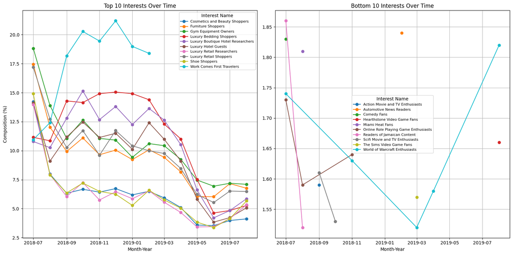